# Final_report

Impacts of Typhoons on Landscape Changes in Taipei: A Comparison between Summer 2022 and Summer 2023.

Research Question : How do typhoon events affect landform changes and water quality characteristics in the urban watershed of Taipei?

```python
import rasterio
from rasterio.mask import mask
import numpy as np
import matplotlib.pyplot as plt
from shapely.geometry import box, mapping
import geopandas as gpd
from matplotlib.colors import TwoSlopeNorm
```

Taiwan is one of the most typhoon-prone regions in the world. Each year, during the May to August typhoon season, Taiwan typically experiences 3 to 4 typhoons making landfall. These storms often bring intense rainfall, flooding, and landslides.

What makes 2022 and 2023 interesting for comparison is that they represent two extreme cases:

In 2022, no typhoon made landfall in Taiwan.

In 2023, four powerful typhoons hit Taiwan within a short period.

```python
# T1
red_t1 = 'data/LC09_L2SP_117043_20220722_20230406_02_T1/LC09_L2SP_117043_20220722_20230406_02_T1_SR_B4.TIF'
nir_t1 = 'data/LC09_L2SP_117043_20220722_20230406_02_T1/LC09_L2SP_117043_20220722_20230406_02_T1_SR_B5.TIF'
qa_t1 =  'data/LC09_L2SP_117043_20220722_20230406_02_T1/LC09_L2SP_117043_20220722_20230406_02_T1_QA_PIXEL.TIF'

# T2
red_t2 = 'data/LC09_L2SP_117043_20230911_20230913_02_T1/LC09_L2SP_117043_20230911_20230913_02_T1_SR_B4.TIF'
nir_t2 = 'data/LC09_L2SP_117043_20230911_20230913_02_T1/LC09_L2SP_117043_20230911_20230913_02_T1_SR_B5.TIF'
qa_t2 =  'data/LC09_L2SP_117043_20230911_20230913_02_T1/LC09_L2SP_117043_20230911_20230913_02_T1_QA_PIXEL.TIF'
```

Study Area: Taipei (Tamsui River Basin)

Although this study originally proposed to focus on the Feitsui Reservoir, visual inspection of the satellite imagery revealed that changes were more detectable across the broader Tamsui River Basin, which includes the urban core of Taipei City as well as surrounding hilly terrain and water systems.

```python
# Define bounding box
bbox = [121.3, 24.9, 121.7, 25.2]
bbox_geom = box(*bbox)
bbox_gdf = gpd.GeoDataFrame({'geometry': [bbox_geom]}, crs='EPSG:4326')
```

First, I applied the cloud and shadow masking method using the QA_PIXEL band.

```python
# Function : cloud mask
def apply_cloud_mask(image_array, qa_array):
    cloud_shadow_bit = 1 << 3  # Cloud shadow
    cloud_bit = 1 << 4  # Cloud
    mask = ((qa_array & cloud_shadow_bit) == 0) & ((qa_array & cloud_bit) == 0)
    return np.where(mask, image_array, np.nan)
```

```python
# Function: calculate NDVI
def get_ndvi(red_path, nir_path, qa_path, bbox_gdf):
    with rasterio.open(red_path) as red_src:
        bbox_proj = bbox_gdf.to_crs(red_src.crs)
        red_crop, _ = mask(red_src, [mapping(bbox_proj.iloc[0].geometry)], crop=True)

    with rasterio.open(nir_path) as nir_src:
        nir_crop, _ = mask(nir_src, [mapping(bbox_proj.iloc[0].geometry)], crop=True)

    with rasterio.open(qa_path) as qa_src:
        qa_crop, _ = mask(qa_src, [mapping(bbox_proj.iloc[0].geometry)], crop=True)

    red = red_crop[0].astype('float32')
    nir = nir_crop[0].astype('float32')
    qa = qa_crop[0]

    red_masked = apply_cloud_mask(red, qa)
    nir_masked = apply_cloud_mask(nir, qa)

    ndvi = (nir_masked - red_masked) / (nir_masked + red_masked)
    ndvi = np.where((nir_masked + red_masked) == 0, np.nan, ndvi)
    return ndvi
```

To assess vegetation changes before and after typhoon events, I calculated the NDVI for the summers of 2022 and 2023. NDVI is a commonly used spectral index that measures vegetation density and health by comparing the reflectance in the NIR and red bands of satellite imagery.

```python
# Calculate NDVI
ndvi_1 = get_ndvi(red_t1, nir_t1, qa_t1, bbox_gdf)
ndvi_2 = get_ndvi(red_t2, nir_t2, qa_t2, bbox_gdf)

# difference
ndvi_diff = ndvi_2 - ndvi_1
```

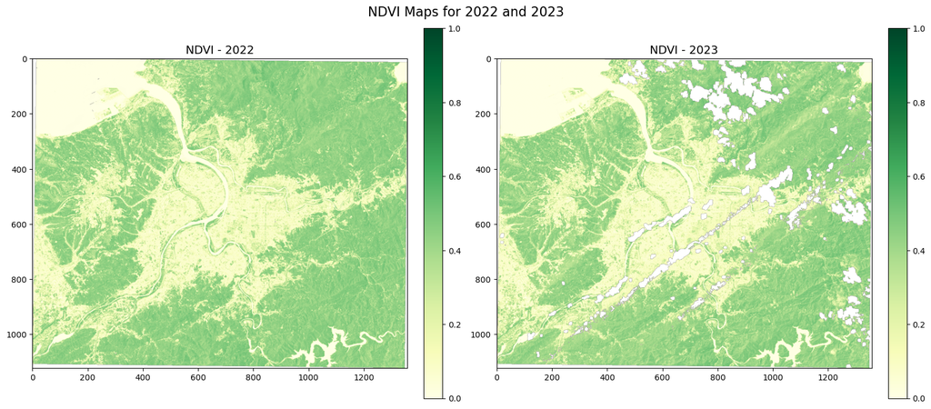

```python
# Plot NDVI maps for 2022 and 2023
fig, axs = plt.subplots(1, 2, figsize=(16, 7))

# NDVI 2022
im1 = axs[0].imshow(ndvi_1, cmap='YlGn', vmin=0, vmax=1)
axs[0].set_title('NDVI - 2022', fontsize=14)
fig.colorbar(im1, ax=axs[0], fraction=0.046, pad=0.04)

# NDVI 2023
im2 = axs[1].imshow(ndvi_2, cmap='YlGn', vmin=0, vmax=1)
axs[1].set_title('NDVI - 2023', fontsize=14)
fig.colorbar(im2, ax=axs[1], fraction=0.046, pad=0.04)

plt.suptitle('NDVI Maps for 2022 and 2023', fontsize=16)
plt.tight_layout()
plt.savefig('ndvi_maps_2022_2023.png', dpi=300)
plt.show()
```

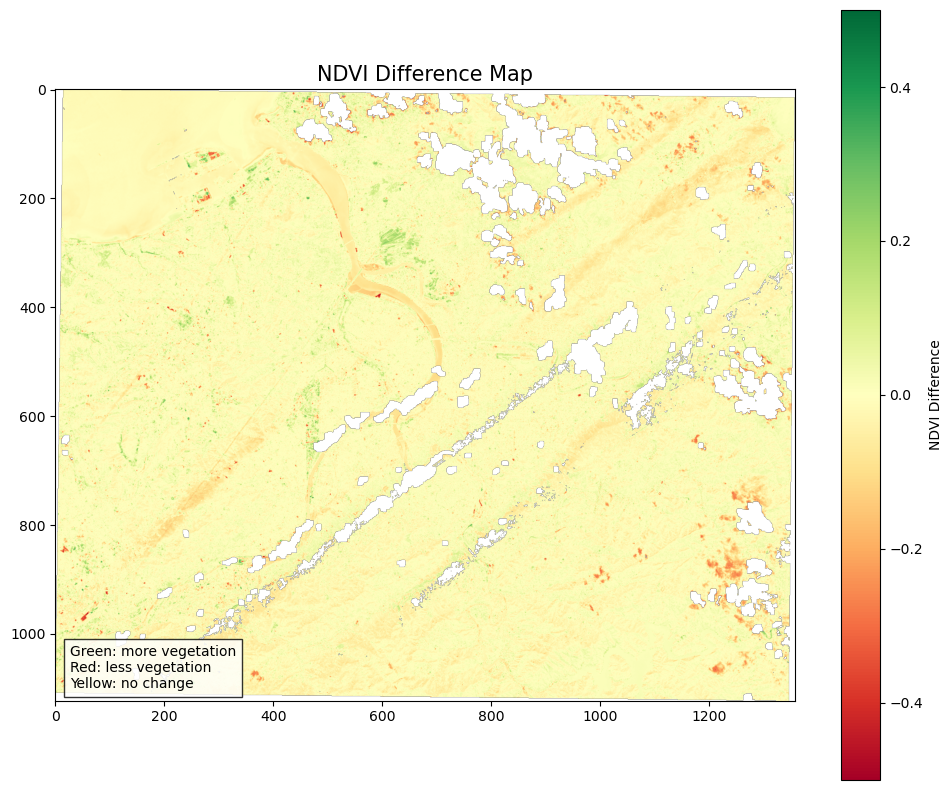

```python
# Plot difference map
plt.figure(figsize=(10, 8))
norm = TwoSlopeNorm(vmin=-0.5, vcenter=0, vmax=0.5)
im = plt.imshow(ndvi_diff, cmap='RdYlGn', norm=norm)
plt.colorbar(im, label='NDVI Difference')
plt.title('NDVI Difference Map', fontsize=15)
plt.text(0.02, 0.02,
         'Green: more vegetation\nRed: less vegetation\nYellow: no change',
         transform=plt.gca().transAxes,
         bbox=dict(facecolor='white', alpha=0.8))
plt.tight_layout()
plt.savefig('ndvi_diff_map.png', dpi=300)
plt.show()
```

Green areas represent an increase in NDVI, indicating potential vegetation recovery or growth.

Red areas represent a decrease in NDVI, possibly due to vegetation loss from typhoon-related disturbance (e.g., wind damage, flooding, or landslides).

Yellow areas represent minimal or no change.

The spatial pattern of NDVI difference suggests that localized vegetation loss occurred in parts of the Tamsui River Basin in 2023, likely as a result of landslides caused by heavy typhoon rainfall and wind. Meanwhile, some areas showed vegetation regrowth or increased greenness, possibly due to seasonal recovery or less human disturbance.

To evaluate changes in the water extent, I calculated the NDWI for the summers of 2022 and 2023. NDWI is designed to enhance open water features. It's computed using the Green(B3) and NIR (B5) bands.

```python
green_2022 = 'data/LC09_L2SP_117043_20220722_20230406_02_T1/LC09_L2SP_117043_20220722_20230406_02_T1_SR_B3.TIF'
green_2023 = 'data/LC09_L2SP_117043_20230911_20230913_02_T1/LC09_L2SP_117043_20230911_20230913_02_T1_SR_B3.TIF'
```

```python
# Function: calculate NDwI
def get_ndwi(green_path, nir_path, qa_path, bbox_gdf):
    with rasterio.open(green_path) as green_src:
        bbox_proj = bbox_gdf.to_crs(green_src.crs)
        green_crop, _ = mask(green_src, [mapping(bbox_proj.iloc[0].geometry)], crop=True)

    with rasterio.open(nir_path) as nir_src:
        nir_crop, _ = mask(nir_src, [mapping(bbox_proj.iloc[0].geometry)], crop=True)

    with rasterio.open(qa_path) as qa_src:
        qa_crop, _ = mask(qa_src, [mapping(bbox_proj.iloc[0].geometry)], crop=True)

    green = green_crop[0].astype('float32')
    nir = nir_crop[0].astype('float32')
    qa = qa_crop[0]

    green_masked = apply_cloud_mask(green, qa)
    nir_masked = apply_cloud_mask(nir, qa)

    ndwi = (green_masked - nir_masked) / (green_masked + nir_masked)
    ndwi = np.where((green_masked + nir_masked) == 0, np.nan, ndwi)
    return ndwi
```

```python
# Calculate NDWI
ndwi_2022 = get_ndwi(green_2022, nir_t1, qa_t1, bbox_gdf)
ndwi_2023 = get_ndwi(green_2023, nir_t2, qa_t2, bbox_gdf)

# difference
ndwi_diff = ndwi_2023- ndwi_2022
```

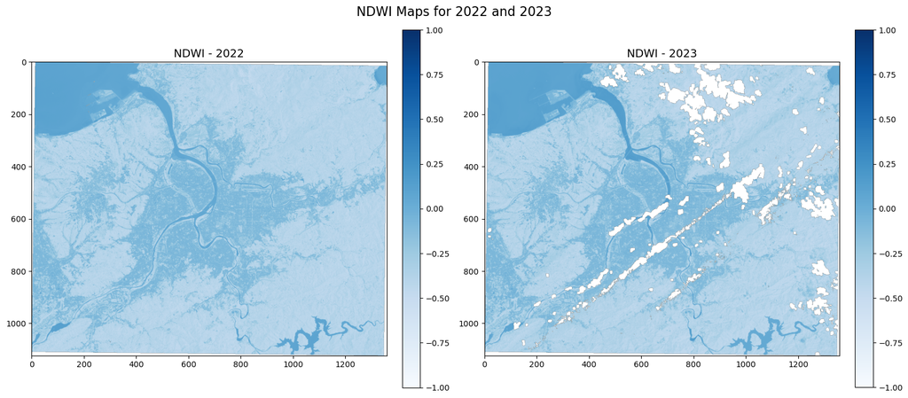

```python
# Plot NDwI maps for 2022 and 2023
fig, axs = plt.subplots(1, 2, figsize=(16, 7))

# NDWI 2022
im1 = axs[0].imshow(ndwi_2022, cmap='Blues', vmin=-1, vmax=1)
axs[0].set_title('NDWI - 2022', fontsize=14)
fig.colorbar(im1, ax=axs[0], fraction=0.046, pad=0.04)

# NDWI 2023
im2 = axs[1].imshow(ndwi_2023, cmap='Blues', vmin=-1, vmax=1)
axs[1].set_title('NDWI - 2023', fontsize=14)
fig.colorbar(im2, ax=axs[1], fraction=0.046, pad=0.04)

plt.suptitle('NDWI Maps for 2022 and 2023', fontsize=16)
plt.tight_layout()
plt.savefig('ndwi_maps_2022_2023.png', dpi=300)
plt.show()
```

[figure not shown]

```python
# Plot difference map for NDWI
plt.figure(figsize=(10, 8))
norm = TwoSlopeNorm(vmin=-0.5, vcenter=0, vmax=0.5)
im = plt.imshow(ndwi_diff, cmap='viridis', norm=norm)
plt.colorbar(im, label='NDWI Difference')
plt.title('NDWI Difference Map', fontsize=15)
plt.text(0.02, 0.02,
         'Blue: more water\nYellow: less water\nWhite: no change',
         transform=plt.gca().transAxes,
         bbox=dict(facecolor='white', alpha=0.8))
plt.tight_layout()
plt.savefig('ndwi_diff_map.png', dpi=300)
plt.show()
```

The NDWI difference map reveals some changes in certain regions:

The river bend areas may experienced riverbank collapse due to heavy rainfall and increased water flow during typhoon events. The changes along the coast are likely due to coastal erosion caused by strong typhoon winds and waves.

```python
import geopandas as gpd
import os
from matplotlib.colors import Normalize
```

For water quality, I used the NDTI index to assess changes in water turbidity.

```python
def calculate_ndti(red_band, green_band):
    """
    Calculate Normalized Difference Turbidity Index
    NDTI = (Red - Green) / (Red + Green)
    """
    # Convert to float
    red = red_band.astype(float)
    green = green_band.astype(float)

    valid_mask = (red + green) != 0
    ndti = np.full_like(red, np.nan, dtype=float)

    # Calculate NDTI
    ndti[valid_mask] = (red[valid_mask] - green[valid_mask]) / (red[valid_mask] + green[valid_mask])

    return ndti
```

```python
def process_landsat_year(year_path, bbox, bands=None):
    """Process Landsat data for a specific year and return cloud-masked NDTI"""
    if bands is None:
        red_band_name = "SR_B4.TIF"   # Red
        green_band_name = "SR_B3.TIF" # Green
    else:
        red_band_name, green_band_name = bands

    files = os.listdir(year_path)
    red_file = [f for f in files if f.endswith(red_band_name)][0]
    green_file = [f for f in files if f.endswith(green_band_name)][0]
    qa_file = [f for f in files if f.endswith("QA_PIXEL.TIF")][0]

    red_band_path = os.path.join(year_path, red_file)
    green_band_path = os.path.join(year_path, green_file)
    qa_path = os.path.join(year_path, qa_file)

    # Define bounding box
    bbox_geom = box(*bbox)
    bbox_gdf = gpd.GeoDataFrame({'geometry': [bbox_geom]}, crs='EPSG:4326')

    # Open and crop red band
    with rasterio.open(red_band_path) as src_red:
        bbox_gdf_proj = bbox_gdf.to_crs(src_red.crs)
        red_cropped, red_transform = mask(src_red, [mapping(bbox_gdf_proj.iloc[0].geometry)], crop=True)
        profile = src_red.profile.copy()

    # Open and crop green band
    with rasterio.open(green_band_path) as src_green:
        green_cropped, _ = mask(src_green, [mapping(bbox_gdf_proj.iloc[0].geometry)], crop=True)

    # Open and crop QA band
    with rasterio.open(qa_path) as src_qa:
        qa_cropped, _ = mask(src_qa, [mapping(bbox_gdf_proj.iloc[0].geometry)], crop=True)

    # cloud mask
    red_masked = apply_cloud_mask(red_cropped[0], qa_cropped[0])
    green_masked = apply_cloud_mask(green_cropped[0], qa_cropped[0])

    # Calculate NDTI with cloud-masked bands
    ndti = calculate_ndti(red_masked, green_masked)

    profile.update({
        'dtype': 'float32',
        'count': 1,
        'transform': red_transform,
        'height': ndti.shape[0],
        'width': ndti.shape[1],
        'nodata': np.nan
    })

    return ndti, profile
```

```
Processing data for year 1...
Processing data for year 2...

Statistics:
year1_mean: -0.0338
year1_median: -0.0456
year1_std: 0.0304
year2_mean: -0.0322
year2_median: -0.0405
year2_std: 0.0275
diff_mean: 0.0016
diff_median: 0.0035
diff_std: 0.0153

Results saved to results directory.
```

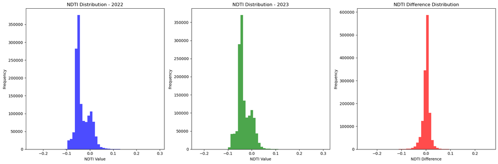

```python
def main():
    # data
    year1_path = 'data/LC09_L2SP_117043_20220722_20230406_02_T1'
    year2_path = 'data/LC09_L2SP_117043_20230911_20230913_02_T1'

    bbox = [121.3, 24.9, 121.7, 25.2]

    # Process data for both years
    print("Processing data for year 1...")
    ndti_year1, profile_year1 = process_landsat_year(year1_path, bbox)

    print("Processing data for year 2...")
    ndti_year2, profile_year2 = process_landsat_year(year2_path, bbox)

    # Save
    output_dir = 'results'
    os.makedirs(output_dir, exist_ok=True)

    with rasterio.open(os.path.join(output_dir, 'ndti_year1.tif'), 'w', **profile_year1) as dst:
        dst.write(ndti_year1.astype(rasterio.float32), 1)

    with rasterio.open(os.path.join(output_dir, 'ndti_year2.tif'), 'w', **profile_year2) as dst:
        dst.write(ndti_year2.astype(rasterio.float32), 1)

    # difference
    ndti_diff = ndti_year2 - ndti_year1

    with rasterio.open(os.path.join(output_dir, 'ndti_diff.tif'), 'w', **profile_year1) as dst:
        dst.write(ndti_diff.astype(rasterio.float32), 1)

    plt.figure(figsize=(18, 6))

    ndti_vmin = min(np.nanmin(ndti_year1), np.nanmin(ndti_year2))
    ndti_vmax = max(np.nanmax(ndti_year1), np.nanmax(ndti_year2))
    ndti_norm = Normalize(vmin=ndti_vmin, vmax=ndti_vmax)

    # Plot year 1 NDTI
    plt.subplot(131)
    im1 = plt.imshow(ndti_year1, cmap='viridis', norm=ndti_norm)
    plt.title('NDTI Year 1 (2022)')
    plt.colorbar(im1, label='NDTI', shrink=0.8)

    # Plot year 2 NDTI
    plt.subplot(132)
    im2 = plt.imshow(ndti_year2, cmap='viridis', norm=ndti_norm)
    plt.title('NDTI Year 2 (2023)')
    plt.colorbar(im2, label='NDTI', shrink=0.8)

    # Plot difference
    plt.subplot(133)
    im3 = plt.imshow(ndti_diff, cmap='RdBu', vmin=-0.2, vmax=0.2)
    plt.title('NDTI Difference (Year 2 - Year 1)')
    plt.colorbar(im3, label='NDTI Difference', shrink=0.8)

    plt.tight_layout()
    plt.savefig(os.path.join(output_dir, 'ndti_comparison.png'), dpi=300)
    plt.close()

    # Calculate statistics
    valid_mask = ~np.isnan(ndti_year1) & ~np.isnan(ndti_year2)
    ndti_year1_valid = ndti_year1[valid_mask]
    ndti_year2_valid = ndti_year2[valid_mask]
    ndti_diff_valid = ndti_diff[valid_mask]

    stats = {
        'year1_mean': np.mean(ndti_year1_valid),
        'year1_median': np.median(ndti_year1_valid),
        'year1_std': np.std(ndti_year1_valid),
        'year2_mean': np.mean(ndti_year2_valid),
        'year2_median': np.median(ndti_year2_valid),
        'year2_std': np.std(ndti_year2_valid),
        'diff_mean': np.mean(ndti_diff_valid),
        'diff_median': np.median(ndti_diff_valid),
        'diff_std': np.std(ndti_diff_valid)
    }

    print("\nStatistics:")
    for key, value in stats.items():
        print(f"{key}: {value:.4f}")

    # Create histogram
    plt.figure(figsize=(18, 6))

    plt.subplot(131)
    plt.hist(ndti_year1_valid.flatten(), bins=50, alpha=0.7, color='blue')
    plt.title('NDTI Distribution - 2022')
    plt.xlabel('NDTI Value')
    plt.ylabel('Frequency')

    plt.subplot(132)
    plt.hist(ndti_year2_valid.flatten(), bins=50, alpha=0.7, color='green')
    plt.title('NDTI Distribution - 2023')
    plt.xlabel('NDTI Value')
    plt.ylabel('Frequency')

    plt.subplot(133)
    plt.hist(ndti_diff_valid.flatten(), bins=50, alpha=0.7, color='red')
    plt.title('NDTI Difference Distribution')
    plt.xlabel('NDTI Difference')
    plt.ylabel('Frequency')

    plt.tight_layout()
    plt.savefig(os.path.join(output_dir, 'ndti_histograms.png'), dpi=300)

    print(f"\nResults saved to {output_dir} directory.")

if __name__ == "__main__":
    main()
```

NDTI < 0 means green band reflectance is higher than red band reflectance -- Relatively clear water

NDTI > 0 means red band reflectance is higher than green band reflectance -- Turbid or water with more suspended material

The mean NDTI in 2022 was -0.0338, with a standard deviation of 0.0304. In 2023, the mean NDTI increased slightly to -0.0322, with a standard deviation of 0.0275.

The overall difference is +0.0016.

This small but positive change indicates a slight increase in water turbidity after the typhoons. This makes sense because typhoons can bring heavy rainfall that washes sediments and pollutants into reservoirs, temporarily decreasing water quality.

Conclusion

Key findings include:

NDVI difference maps showed localized vegetation loss in areas likely affected by landslides or wind damage, and limited vegetation regrowth in other zones.

NDWI increased in some riverine areas, likely indicating temporary flooding or water expansion during or after storm events.

These results support the use of spectral indices as effective tools for detecting post-disaster environmental changes. The analysis also highlights the value of satellite data for assessing hydrological responses to extreme weather in highly urbanized regions.

Limitations

Several limitations affect the interpretation of results:

1. The 30-meter resolution of Landsat imagery limits detection of fine-scale urban or water changes.
2. The analysis is based on two time points, which cannot capture intra-seasonal variation or long-term trends.
3. NDVI and NDWI values may also be affected by seasonal phenology, not just typhoon events.
4. QA cloud masking may leave residual atmospheric effects.

Moving Forward

1. Temporal extension: Incorporating multi-year imagery would allow assessment of interannual variability and long-term resilience.
2. Using Sentinel-2 (10m) or PlanetScope (~3–5m) imagery would improve detection in dense urban or complex river systems.
3. Combining with rain gauge data, stream discharge, and water quality monitoring would provide a more comprehensive view.
4. Machine learning: Automated land cover change detection could complement index-based approaches.

By continuing to monitor and analyze storm-induced environmental change, we can support climate adaptation, urban planning, and disaster preparedness in cities like Taipei.

```python
!jupyter nbconvert Final_report.ipynb --to html
```

[output not shown]